# Implicit Conceptual PT Data Analysis (for SAP requirement)

Kathryn Denning

2/14/2020

# Introduction to study

This study looked at whether people consider the conceptual perspectives (e.g., likes) of others without conscious awareness, and if this depends on whether the target individual has the same visibility of the target stimuli as them. Participants were asked to respond about how much they liked the stimuli after being trained on the targets’ likes and dislikes. Implicit conceptual perspective taking would be found if people are slower to respond on inconsistent trials in comparison to consistent trials.

**Variable names included in the analysis:**

- **consistent**: Whether the participant had the same conceptual perspective as the target or not. Helemert contrasts were applied to this categorical variable.
  - consistent: perspectives about whether or not they liked the stimuli were the same
  - inconsistent: perspectives were different
  - unknown: the participant does not know the target’s perspective
  - dislike: the participant dislikes the stimuli; included as a comparison so that participants were not only responding “like” the entire time
- **visibility**: Whether the target individual can see the food stimuli or not.
- **exp_resp.rt** : Reaction time on trials in seconds.

# Looking at data

## Checking for outliers and filtering responses over 3 seconds

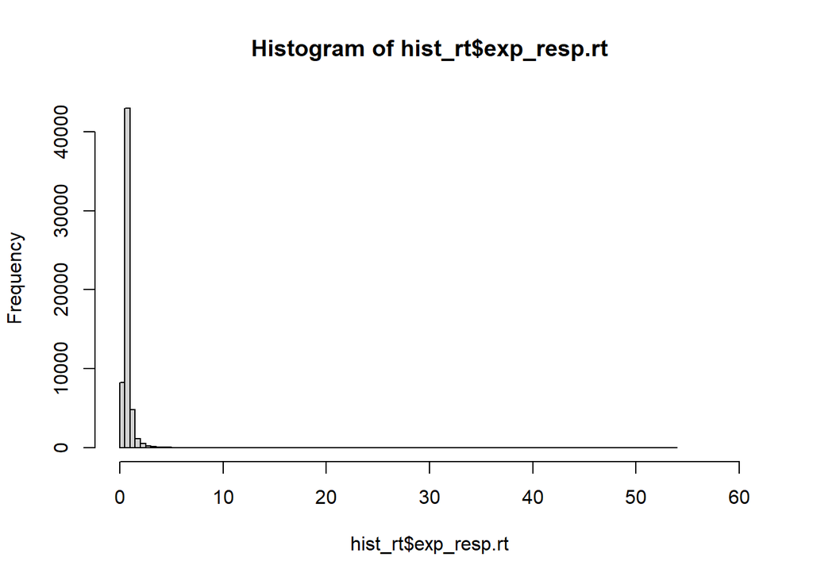

```r
# Checking outliers in reaction time overall
hist_rt <- dat_analysis %>%
  select(participant, exp_resp.rt) %>%
  unique()
hist(hist_rt$exp_resp.rt, xlim = c(0, 60), breaks = 150)
```

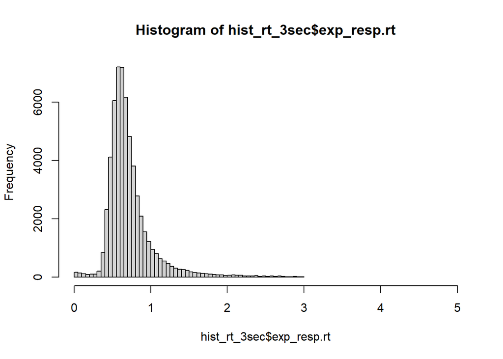

```r
# Removing trials that took over 3 seconds to respond
data_rt <- dat_analysis %>%
  filter(exp_resp.rt < 3.0)

# Re-checking for outliers in reaction time overall
hist_rt_3sec <- data_rt %>%
  select(participant, exp_resp.rt) %>%
  unique()
hist(hist_rt_3sec$exp_resp.rt, xlim = c(0, 5), breaks = 50)
```

```r
# percent removed over 3 seconds
(1 - nrow(data_rt)/nrow(dat_analysis))*100
```

```
## [1] 1.301762
```

## Descriptives before removing error trials

### Mean and SD for reaction time by consistency condition

```r
# aggregating responses per participant
data_aggregated_werror <- data_rt %>%
  group_by(participant, consistent, visibility) %>%
  summarize(rt_pagg = mean(exp_resp.rt))

consistency_werror <- data_aggregated_werror %>%
  select(participant, consistent, rt_pagg) %>%
  na.omit() %>%
  group_by(consistent) %>%
  summarize(mean = mean(rt_pagg),
            sd = sd(rt_pagg),
            se = sd(rt_pagg)/sqrt(length(rt_pagg)))
consistency_werror
```

```
## # A tibble: 4 x 4
##   consistent    mean    sd      se
##   <fct>        <dbl> <dbl>   <dbl>
## 1 Consistent   0.723 0.184 0.0134
## 2 Inconsistent 0.735 0.203 0.0148
## 3 Unknown      0.709 0.147 0.0108
## 4 Dislike      0.723 0.129 0.00939
```

### Mean and SD for reaction time by visibility condition

```r
visibility_werror <- data_aggregated_werror %>%
  select(participant, visibility, rt_pagg) %>%
  na.omit() %>%
  group_by(visibility) %>%
  summarize(mean = mean(rt_pagg),
            sd = sd(rt_pagg),
            se = sd(rt_pagg)/sqrt(length(rt_pagg)))
visibility_werror
```

```
## # A tibble: 2 x 4
##   visibility   mean    sd      se
##   <fct>       <dbl> <dbl>   <dbl>
## 1 Not Visible 0.725 0.171 0.00881
## 2 Visible     0.720 0.166 0.00854
```

### Combined table for reaction time with both visibility and consistency with error

```r
combined_werror <- data_aggregated_werror %>%
  select(participant, visibility, consistent, rt_pagg) %>%
  na.omit() %>%
  group_by(visibility, consistent) %>%
  summarize(mean = mean(rt_pagg),
            sd = sd(rt_pagg),
            se = sd(rt_pagg)/sqrt(length(rt_pagg)))
combined_werror
```

```
## # A tibble: 8 x 5
## # Groups:   visibility [2]
##   visibility  consistent    mean    sd     se
##   <fct>       <fct>        <dbl> <dbl>  <dbl>
## 1 Not Visible Consistent   0.725 0.187 0.0192
## 2 Not Visible Inconsistent 0.740 0.205 0.0212
## 3 Not Visible Unknown      0.711 0.153 0.0158
## 4 Not Visible Dislike      0.726 0.130 0.0134
## 5 Visible     Consistent   0.721 0.182 0.0187
## 6 Visible     Inconsistent 0.731 0.202 0.0208
## 7 Visible     Unknown      0.707 0.142 0.0147
## 8 Visible     Dislike      0.720 0.128 0.0132
```

### Overall variable descriptives

```r
data_aggregated_werror %>%
  select(visibility, consistent, rt_pagg) %>%
  describe()
```

```
##             vars   n  mean    sd median trimmed   mad  min    max range  skew
## participant    1 752 52.05 28.60  52.50   52.22 36.32 2.00 101.00 99.00 -0.03
## visibility*    2 752  1.50  0.50   1.50    1.50  0.74 1.00   2.00  1.00  0.00
## consistent*    3 752  2.50  1.12   2.50    2.50  1.48 1.00   4.00  3.00  0.00
## rt_pagg        4 752  0.72  0.17   0.68    0.69  0.11 0.47   1.48  1.01  1.85
##             kurtosis   se
## participant    -1.20 1.04
## visibility*    -2.00 0.02
## consistent*    -1.36 0.04
## rt_pagg         3.85 0.01
```

## Descriptives after removing error trials

### Mean and SD for reaction time by consistency condition

```r
data_aggregated_nerror <- data_rt %>%
  filter(error != "Error") %>%
  droplevels(data_rt$error) %>%
  na.omit() %>%
  group_by(participant, consistent, visibility) %>%
  summarize(rt_pagg = mean(exp_resp.rt))

consistency_nerror <- data_aggregated_nerror %>%
  select(participant, consistent, rt_pagg) %>%
  na.omit() %>%
  group_by(consistent) %>%
  summarize(mean = mean(rt_pagg),
            sd = sd(rt_pagg),
            se = sd(rt_pagg)/sqrt(length(rt_pagg)))
consistency_nerror
```

```
## # A tibble: 4 x 4
##   consistent    mean    sd      se
##   <fct>        <dbl> <dbl>   <dbl>
## 1 Consistent   0.721 0.182 0.0133
## 2 Inconsistent 0.729 0.196 0.0143
## 3 Unknown      0.709 0.144 0.0105
## 4 Dislike      0.734 0.128 0.00933
```

### Mean and SD for reaction time by visibility condition

```r
visibility_nerror <- data_aggregated_nerror %>%
  select(participant, visibility, rt_pagg) %>%
  na.omit() %>%
  group_by(visibility) %>%
  summarize(mean = mean(rt_pagg),
            sd = sd(rt_pagg),
            se = sd(rt_pagg)/sqrt(length(rt_pagg)))
visibility_nerror
```

```
## # A tibble: 2 x 4
##   visibility   mean    sd      se
##   <fct>       <dbl> <dbl>   <dbl>
## 1 Not Visible 0.726 0.167 0.00860
## 2 Visible     0.721 0.163 0.00840
```

### Combined table for reaction time with both visibility and consistency without error

```r
combined_nerror <- data_aggregated_nerror %>%
  select(participant, visibility, consistent, rt_pagg) %>%
  na.omit() %>%
  group_by(visibility, consistent) %>%
  summarize(mean = mean(rt_pagg),
            sd = sd(rt_pagg),
            se = sd(rt_pagg)/sqrt(length(rt_pagg)))
combined_nerror
```

```
## # A tibble: 8 x 5
## # Groups:   visibility [2]
##   visibility  consistent    mean    sd     se
##   <fct>       <fct>        <dbl> <dbl>  <dbl>
## 1 Not Visible Consistent   0.723 0.185 0.0191
## 2 Not Visible Inconsistent 0.732 0.194 0.0200
## 3 Not Visible Unknown      0.712 0.150 0.0155
## 4 Not Visible Dislike      0.737 0.131 0.0135
## 5 Visible     Consistent   0.720 0.180 0.0186
## 6 Visible     Inconsistent 0.726 0.198 0.0204
## 7 Visible     Unknown      0.706 0.139 0.0143
## 8 Visible     Dislike      0.731 0.125 0.0129
```

### Overall variable descriptives

```r
data_aggregated_nerror %>%
  select(visibility, consistent, rt_pagg) %>%
  describe()
```

```
##             vars   n  mean    sd median trimmed   mad  min    max range  skew
## participant    1 752 52.05 28.60  52.50   52.22 36.32 2.00 101.00 99.00 -0.03
## visibility*    2 752  1.50  0.50   1.50    1.50  0.74 1.00   2.00  1.00  0.00
## consistent*    3 752  2.50  1.12   2.50    2.50  1.48 1.00   4.00  3.00  0.00
## rt_pagg        4 752  0.72  0.16   0.68    0.70  0.11 0.48   1.51  1.03  1.82
##             kurtosis   se
## participant    -1.20 1.04
## visibility*    -2.00 0.02
## consistent*    -1.36 0.04
## rt_pagg         3.82 0.01
```

## Percent of error trials vs correct trials

```r
# Percent error
data_rt %>%
  select(error) %>%
  group_by(error) %>%
  count() %>%
  mutate(percent = n/(3509+57222)*100)
```

```
## # A tibble: 2 x 3
## # Groups:   error [2]
##   error       n percent
##   <fct>   <int>   <dbl>
## 1 Correct 57222   94.2
## 2 Error    3509    5.78
```

# Model predicting RT

## Contrasts

```r
# Removing dislike condition from anaysis as it was just a methodological variation not theoretically related to analysis
# Removing errors from analysis
anova_rt_data <- data_rt %>%
  mutate(participant = as.factor(participant)) %>%
  filter(error != "Error") %>%
  filter(consistent != "Dislike") %>%
  droplevels(data_rt$error) %>%
  droplevels(data_rt$consistent) %>%
  na.omit() %>%
  group_by(participant, consistent, visibility) %>%
  mutate(rt_pagg = mean(exp_resp.rt)) %>%
  select(participant, consistent, visibility, visibility_effects, rt_pagg) %>%
  unique() %>%
  na.omit()

CIvU <- c(-1, -1, 2)
CvI <- c(-1, 1, 0)
ConCodes <- cbind(CIvU, CvI)
contrasts(anova_rt_data$consistent) <- ConCodes
contrasts(anova_rt_data$consistent)
```

```
##              CIvU CvI
## Consistent     -1  -1
## Inconsistent   -1   1
## Unknown         2   0
```

*Visibility was effects coded*

## Results

```r
model1 <- aov_car(rt_pagg ~ Error(participant/(visibility_effects*consistent)),
                      data = anova_rt_data, anova_table = list(p_adjust_method = "bonferroni"))

summary(model1) #without bonferroni adjustment
```

```
##
## Univariate Type III Repeated-Measures ANOVA Assuming Sphericity
##
##                                Sum Sq num Df Error SS den Df   F value  Pr(>F)
## (Intercept)                   292.090      1  15.7609     93 1723.5295 < 2e-16
## visibility_effects              0.004      1   0.1025     93    3.2152 0.07621
## consistent                      0.037      2   1.2006    186    2.9033 0.05733
## visibility_effects:consistent   0.000      2   0.2020    186    0.0984 0.90638
##
## (Intercept)                   ***
## visibility_effects            .
## consistent                    .
## visibility_effects:consistent
## ---
## Signif. codes:  0 '***' 0.001 '**' 0.01 '*' 0.05 '.' 0.1 ' ' 1
##
##
## Mauchly Tests for Sphericity
##
##                               Test statistic    p-value
## consistent                           0.40970 0.00000000
## visibility_effects:consistent        0.81948 0.00010539
##
##
## Greenhouse-Geisser and Huynh-Feldt Corrections
##  for Departure from Sphericity
##
##                                GG eps Pr(>F[GG])
## consistent                    0.62881    0.08179 .
## visibility_effects:consistent 0.84709    0.87599
## ---
## Signif. codes:  0 '***' 0.001 '**' 0.01 '*' 0.05 '.' 0.1 ' ' 1
##
##                                  HF eps Pr(>F[HF])
## consistent                    0.6333847 0.08144483
## visibility_effects:consistent 0.8611286 0.87919575
```

```r
nice(model1) #with bonferroni adjustment
```

```
## Anova Table (Type 3 tests, bonferroni-adjusted)
##
## Response: rt_pagg
##                          Effect           df  MSE    F   ges p.value
## 1            visibility_effects        1, 93 0.00 3.22 <.001    .229
## 2                    consistent 1.26, 116.96 0.01 2.90  .002    .245
## 3 visibility_effects:consistent 1.69, 157.56 0.00 0.10 <.001   >.999
## ---
## Signif. codes:  0 '***' 0.001 '**' 0.01 '*' 0.05 '+' 0.1 ' ' 1
##
## Sphericity correction method: GG
```

```r
# Using emmeans to get marginal means for pairwise comparisons - smooth code for marginal means! These look like what I get when I hard code this by hand using dplyr
mm_consistent_model1 <- emmeans(model1, ~ consistent)

# Tukey pairwise comparisons - what I expected from the plots
pairs(mm_consistent_model1)
```

```
##  contrast                  estimate      SE  df t.ratio p.value
##  Consistent - Inconsistent -0.00745 0.00829 186 -0.899  0.6416
##  Consistent - Unknown       0.01232 0.00829 186  1.487  0.2996
##  Inconsistent - Unknown     0.01977 0.00829 186  2.386  0.0472
##
## Results are averaged over the levels of: visibility_effects
## P value adjustment: tukey method for comparing a family of 3 estimates
```

## Plots

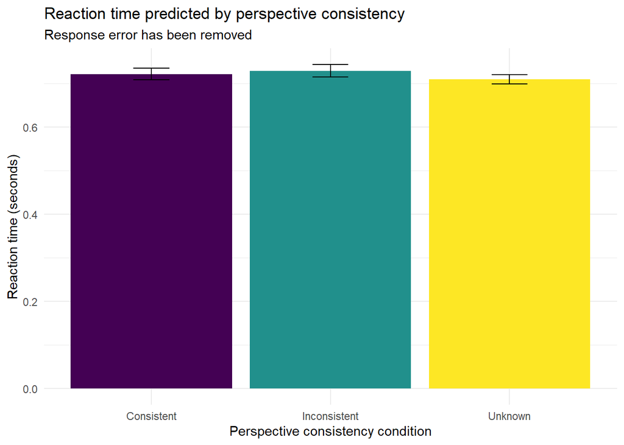

```r
# Dropping dislike option from plot
consistency_nerror_ndislike <-  consistency_nerror %>%
  filter(consistent != "Dislike") %>%
  droplevels(consistency_nerror$consistent) %>%
  na.omit()

ggplot(consistency_nerror_ndislike, aes(x = consistent, y = mean, fill = consistent)) +
  geom_bar(stat = "identity") +
  theme_minimal() +
  scale_fill_viridis_d() +
  theme(legend.position = "none") +
  labs(title = "Reaction time predicted by perspective consistency",
       subtitle = "Response error has been removed",
       x = "Perspective consistency condition",
       y = "Reaction time (seconds)") +
  geom_errorbar(aes(ymin = mean - se, ymax = mean + se), width = .2,
                position = position_dodge(.9))
```

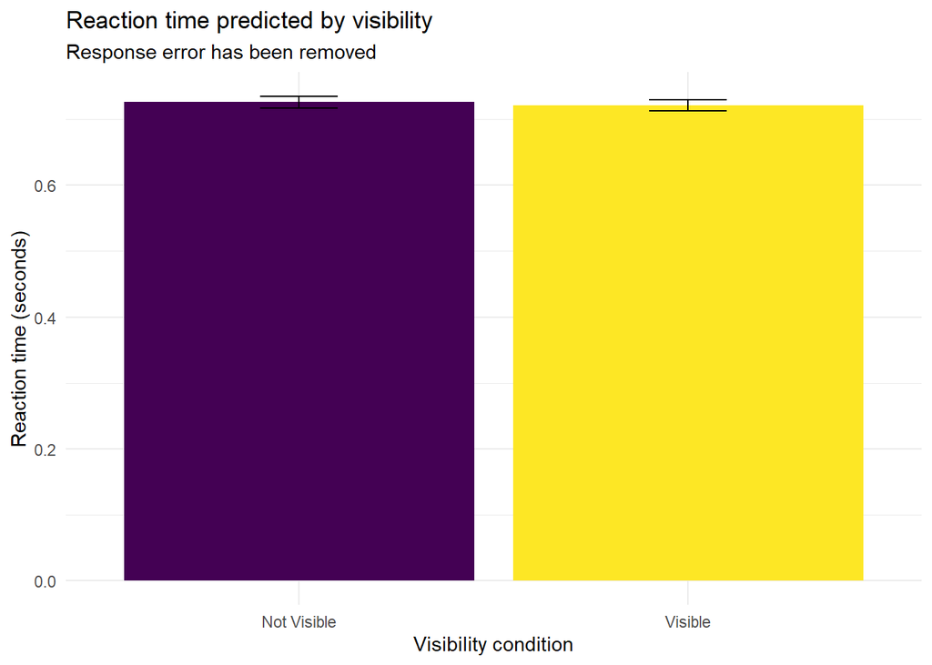

```r
ggplot(visibility_nerror , aes(x = visibility, y = mean, fill = visibility)) +
  geom_bar(stat = "identity") +
  theme_minimal() +
  scale_fill_viridis_d() +
  theme(legend.position = "none") +
  labs(title = "Reaction time predicted by visibility",
       subtitle = "Response error has been removed",
       x = "Visibility condition",
       y = "Reaction time (seconds)") +
  geom_errorbar(aes(ymin = mean - se, ymax = mean + se), width = .2,
                position = position_dodge(.9))
```

# Model predicting error

## Contrasts

```r
# Organizing data to include both levels of error but get rid of the dislike condition
anova_error_data <- data_rt %>%
  filter(consistent != "Dislike") %>%
  droplevels(data_rt$consistent) %>%
  na.omit() %>%
  group_by(participant, visibility_effects, consistent, error) %>%
  unique() %>%
  count() %>%
  mutate(n_per_grouping = n)

anova_error_data2 <- anova_error_data %>%
  group_by(participant) %>%
  mutate(n_per_total = sum(n_per_grouping)) %>%
  mutate(n_per_grouping = ifelse(error == "Correct", 0, ifelse(error == "Error", n_per_grouping, NA))) %>%
  mutate(error_per_group = (n_per_grouping/n_per_total)*100)

anova_error_data3 <- anova_error_data2 %>%
  group_by(participant, visibility_effects, consistent) %>%
  mutate(error_rate = mean(error_per_group)) %>%
  select(participant, visibility_effects, consistent, error_rate) %>%
  unique()

# Applying helmert contrasts to consistent; visibility is already effects coded
contrasts(anova_error_data3$consistent) <- ConCodes
contrasts(anova_error_data3$consistent)
```

```
##              CIvU CvI
## Consistent     -1  -1
## Inconsistent   -1   1
## Unknown         2   0
```

*Visibility was effects coded*

## Anova results predicting error

```r
# Running logistic regression predicting error
model2 <- aov_car(error_rate ~ Error(participant/(visibility_effects*consistent)),
                      data = anova_error_data3, anova_table = list(p_adjust_method = "bonferroni"))

summary(model2) #without bonferroni adjustment
```

```
##
## Univariate Type III Repeated-Measures ANOVA Assuming Sphericity
##
##                                Sum Sq num Df Error SS den Df F value    Pr(>F)
## (Intercept)                   157.487      1  312.634     93 46.8481 8.068e-10
## visibility_effects              0.010      1    3.339     93  0.2648    0.6081
## consistent                     23.127      2  132.081    186 16.2844 3.041e-07
## visibility_effects:consistent   0.026      2    7.879    186  0.3094    0.7343
##
## (Intercept)                   ***
## visibility_effects
## consistent                    ***
## visibility_effects:consistent
## ---
## Signif. codes:  0 '***' 0.001 '**' 0.01 '*' 0.05 '.' 0.1 ' ' 1
##
##
## Mauchly Tests for Sphericity
##
##                               Test statistic    p-value
## consistent                           0.29075 0.0000e+00
## visibility_effects:consistent        0.69642 5.9157e-08
##
##
## Greenhouse-Geisser and Huynh-Feldt Corrections
##  for Departure from Sphericity
##
##                                GG eps Pr(>F[GG])
## consistent                    0.58505  4.067e-05 ***
## visibility_effects:consistent 0.76712     0.6757
## ---
## Signif. codes:  0 '***' 0.001 '**' 0.01 '*' 0.05 '.' 0.1 ' ' 1
##
##                                  HF eps   Pr(>F[HF])
## consistent                    0.5879895 3.927575e-05
## visibility_effects:consistent 0.7774381 6.786821e-01
```

```r
nice(model2) #with bonferroni adjustment
```

```
## Anova Table (Type 3 tests, bonferroni-adjusted)
##
## Response: error_rate
##                          Effect           df  MSE         F   ges p.value
## 1            visibility_effects        1, 93 0.04      0.26 <.001   >.999
## 2                    consistent 1.17, 108.82 1.21 16.28 ***  .048   <.001
## 3 visibility_effects:consistent 1.53, 142.68 0.06      0.31 <.001   >.999
## ---
## Signif. codes:  0 '***' 0.001 '**' 0.01 '*' 0.05 '+' 0.1 ' ' 1
##
## Sphericity correction method: GG
```

```r
# Using emmeans to get marginal means for pairwise comparisons - smooth code for marginal means! These look like what I get when I hard code this by hand using dplyr
mm_consistent_model2 <- emmeans(model2, ~ consistent)

# Tukey pairwise comparisons - what I expected from the plots
pairs(mm_consistent_model2)
```

```
##  contrast                  estimate     SE  df t.ratio p.value
##  Consistent - Inconsistent   -0.358 0.0869 186 -4.118  0.0002
##  Consistent - Unknown        -0.476 0.0869 186 -5.481  <.0001
##  Inconsistent - Unknown      -0.118 0.0869 186 -1.362  0.3629
##
## Results are averaged over the levels of: visibility_effects
## P value adjustment: tukey method for comparing a family of 3 estimates
```

## Plot and descriptives for main effect of consistency

```r
data_aggregated_errorrate <- anova_error_data3 %>%
  select(participant, consistent, error_rate) %>%
  na.omit() %>%
  group_by(consistent) %>%
  summarize(mean = mean(error_rate),
            sd = sd(error_rate),
            se = sd(error_rate)/sqrt(length(error_rate)))
data_aggregated_errorrate
```

```
## # A tibble: 3 x 4
##   consistent    mean    sd     se
##   <fct>        <dbl> <dbl>  <dbl>
## 1 Consistent   0.250 0.381 0.0278
## 2 Inconsistent 0.608 1.06  0.0776
## 3 Unknown      0.727 1.08  0.0786
```

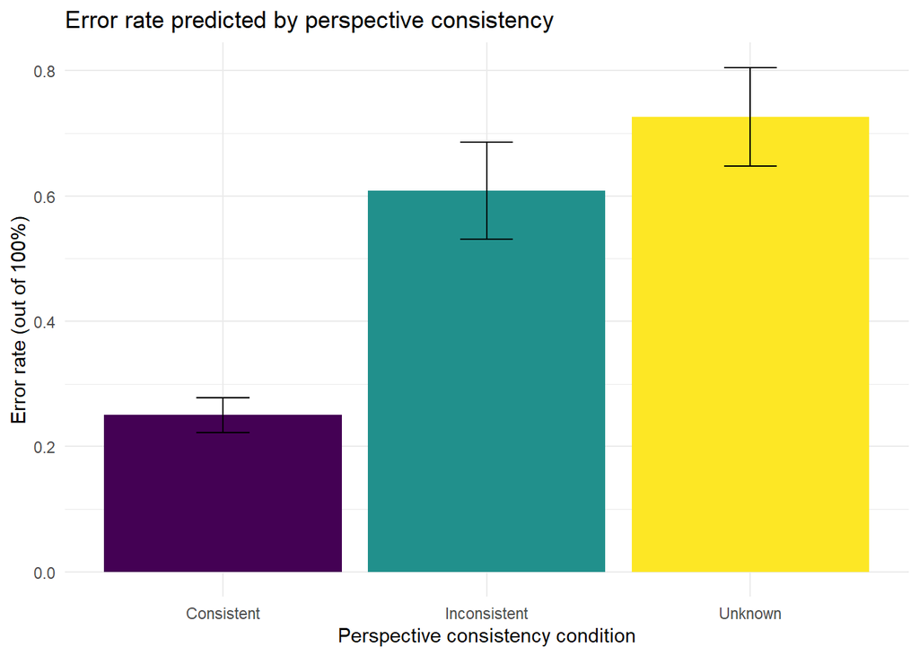

```r
ggplot(data_aggregated_errorrate, aes(x = consistent, y = mean, fill = consistent)) +
  geom_bar(stat = "identity") +
  theme_minimal() +
  scale_fill_viridis_d() +
  theme(legend.position = "none") +
  labs(title = "Error rate predicted by perspective consistency",
       x = "Perspective consistency condition",
       y = "Error rate (out of 100%)") +
  geom_errorbar(aes(ymin = mean - se, ymax = mean + se), width = .2,
                position = position_dodge(.9))
```

## Descriptives for visibility

```r
data_aggregated_errorrate_vis <- anova_error_data3 %>%
  select(participant, visibility_effects, error_rate) %>%
  na.omit() %>%
  group_by(visibility_effects) %>%
  summarize(mean = mean(error_rate),
            sd = sd(error_rate),
            se = sd(error_rate)/sqrt(length(error_rate)))
data_aggregated_errorrate_vis
```

```
## # A tibble: 2 x 4
##   visibility_effects  mean    sd     se
##   <fct>              <dbl> <dbl>  <dbl>
## 1 .5                 0.524 0.909 0.0542
## 2 -.5                0.533 0.937 0.0558
```

# Model predicting RT with block as predictor

```r
# Removing dislike condition from anaysis as it was just a methodological variation not theoretically related to analysis
# Removing errors from analysis
anova_rt_block_data <- data_rt %>%
  filter(error != "Error") %>%
  filter(consistent != "Dislike") %>%
  droplevels(data_rt$error) %>%
  droplevels(data_rt$consistent) %>%
  na.omit() %>%
  group_by(participant, consistent, visibility, expBlock.thisN) %>%
  mutate(rt_pagg = mean(exp_resp.rt)) %>%
  select(participant, consistent, visibility, visibility_effects, rt_pagg, expBlock.thisN) %>%
  unique() %>%
  na.omit()

CIvU <- c(-1, -1, 2)
CvI <- c(-1, 1, 0)
ConCodes <- cbind(CIvU, CvI)
contrasts(anova_rt_block_data$consistent) <- ConCodes
contrasts(anova_rt_block_data$consistent)
```

```
##              CIvU CvI
## Consistent     -1  -1
## Inconsistent   -1   1
## Unknown         2   0
```

*Visibility was effects coded*

## Results

```r
# Running the repeated measures anova

model3 <- aov_car(rt_pagg ~ Error(participant/(visibility_effects*consistent*expBlock.thisN)),
                      data = anova_rt_block_data, anova_table = list(p_adjust_method = "bonferroni"))

summary(model3) #without bonferroni adjustment
```

```
##
## Univariate Type III Repeated-Measures ANOVA Assuming Sphericity
##
##                                               Sum Sq num Df Error SS den Df
## (Intercept)                                  2459.91      1  109.207     90
## visibility_effects                              0.03      1    0.729     90
## consistent                                      0.34      2    9.958    180
## expBlock.thisN                                  7.84      8   29.061    720
## visibility_effects:consistent                   0.00      2    1.510    180
## visibility_effects:expBlock.thisN               0.10      8    5.625    720
## consistent:expBlock.thisN                       0.13     16   13.085   1440
## visibility_effects:consistent:expBlock.thisN    0.12     16   12.621   1440
##                                                F value  Pr(>F)
## (Intercept)                                  2027.2669 < 2e-16 ***
## visibility_effects                              3.2816 0.07340 .
## consistent                                      3.0986 0.04753 *
## expBlock.thisN                                 24.2899 < 2e-16 ***
## visibility_effects:consistent                   0.2609 0.77068
## visibility_effects:expBlock.thisN               1.6201 0.11537
## consistent:expBlock.thisN                       0.8850 0.58687
## visibility_effects:consistent:expBlock.thisN    0.8600 0.61651
## ---
## Signif. codes:  0 '***' 0.001 '**' 0.01 '*' 0.05 '.' 0.1 ' ' 1
##
##
## Mauchly Tests for Sphericity
##
##                                              Test statistic   p-value
## consistent                                          0.39542 0.0000000
## expBlock.thisN                                      0.05179 0.0000000
## visibility_effects:consistent                       0.89425 0.0069183
## visibility_effects:expBlock.thisN                   0.40373 0.0000306
## consistent:expBlock.thisN                           0.02571 0.0000000
## visibility_effects:consistent:expBlock.thisN        0.04641 0.0000000
##
##
## Greenhouse-Geisser and Huynh-Feldt Corrections
##  for Departure from Sphericity
##
##                                               GG eps Pr(>F[GG])
## consistent                                   0.62321    0.07193 .
## expBlock.thisN                               0.46750    < 2e-16 ***
## visibility_effects:consistent                0.90437    0.74843
## visibility_effects:expBlock.thisN            0.80743    0.13332
## consistent:expBlock.thisN                    0.69130    0.55517
## visibility_effects:consistent:expBlock.thisN 0.70525    0.58214
## ---
## Signif. codes:  0 '***' 0.001 '**' 0.01 '*' 0.05 '.' 0.1 ' ' 1
##
##                                                 HF eps   Pr(>F[HF])
## consistent                                   0.6277211 7.157975e-02
## expBlock.thisN                               0.4902946 1.643230e-17
## visibility_effects:consistent                0.9218299 7.527003e-01
## visibility_effects:expBlock.thisN            0.8765376 1.265396e-01
## consistent:expBlock.thisN                    0.7953328 5.669913e-01
## visibility_effects:consistent:expBlock.thisN 0.8137217 5.959622e-01
```

```r
nice(model3) #with bonferroni adjustment
```

```
## Anova Table (Type 3 tests, bonferroni-adjusted)
##
## Response: rt_pagg
##                                         Effect             df  MSE         F
## 1                           visibility_effects          1, 90 0.01      3.28
## 2                                   consistent   1.25, 112.18 0.09      3.10
## 3                               expBlock.thisN   3.74, 336.60 0.09 24.29 ***
## 4                visibility_effects:consistent   1.81, 162.79 0.01      0.26
## 5            visibility_effects:expBlock.thisN   6.46, 581.35 0.01      1.62
## 6                    consistent:expBlock.thisN  11.06, 995.47 0.01      0.88
## 7 visibility_effects:consistent:expBlock.thisN 11.28, 1015.56 0.01      0.86
##     ges p.value
## 1 <.001    .514
## 2  .002    .503
## 3  .041   <.001
## 4 <.001   >.999
## 5 <.001    .933
## 6 <.001   >.999
## 7 <.001   >.999
## ---
## Signif. codes:  0 '***' 0.001 '**' 0.01 '*' 0.05 '+' 0.1 ' ' 1
##
## Sphericity correction method: GG
```

```r
# Using emmeans to get marginal means for pairwise comparisons - smooth code for marginal means! These look like what I get when I hard code this by hand using dplyr
mm_consistent_model3 <- emmeans(model3, ~ consistent)

# Tukey pairwise comparisons - what I expected from the plots
pairs(mm_consistent_model3)
```

```
##  contrast                  estimate      SE  df t.ratio p.value
##  Consistent - Inconsistent -0.01144 0.00822 180 -1.392  0.3471
##  Consistent - Unknown       0.00897 0.00822 180  1.091  0.5208
##  Inconsistent - Unknown     0.02041 0.00822 180  2.483  0.0369
##
## Results are averaged over the levels of: visibility_effects, expBlock.thisN
## P value adjustment: tukey method for comparing a family of 3 estimates
```

## Plot for consistency

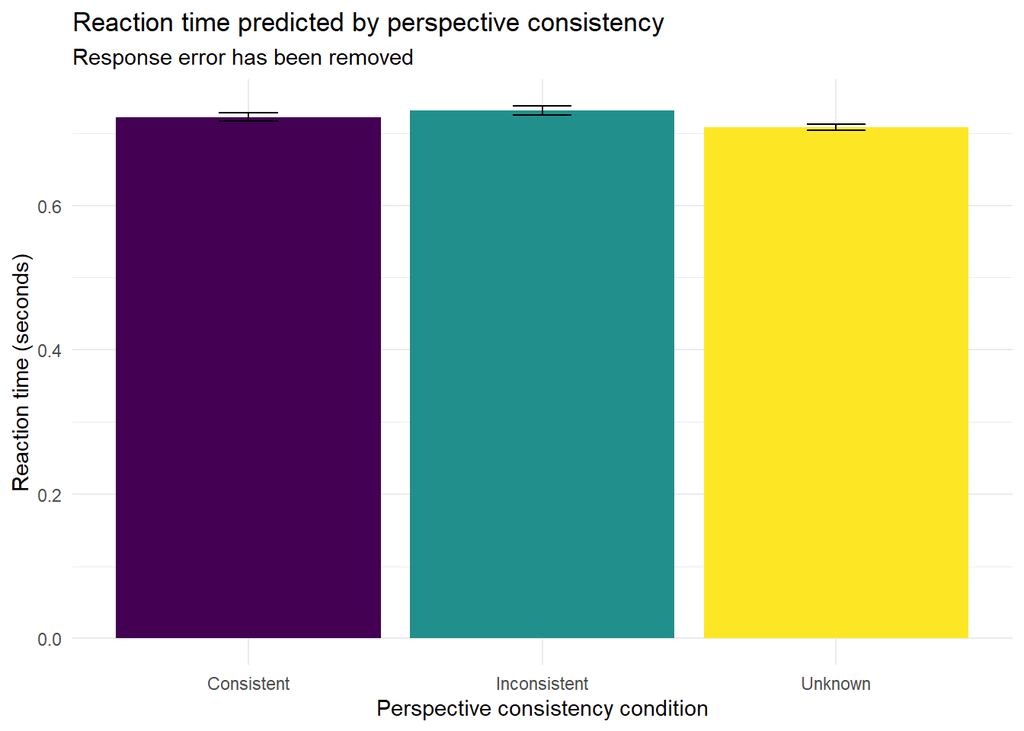

```r
# Plot for consistency
block_model_rt_consistent <- anova_rt_block_data %>%
  select(participant, consistent, rt_pagg) %>%
  na.omit() %>%
  group_by(consistent) %>%
  summarize(mean = mean(rt_pagg),
            sd = sd(rt_pagg),
            se = sd(rt_pagg)/sqrt(length(rt_pagg)))

ggplot(block_model_rt_consistent, aes(x = consistent, y = mean, fill = consistent)) +
  geom_bar(stat = "identity") +
  theme_minimal() +
  scale_fill_viridis_d() +
  theme(legend.position = "none") +
  labs(title = "Reaction time predicted by perspective consistency",
       subtitle = "Response error has been removed",
       x = "Perspective consistency condition",
       y = "Reaction time (seconds)") +
  geom_errorbar(aes(ymin = mean - se, ymax = mean + se), width = .2,
                position = position_dodge(.9))
```

## Plot for block

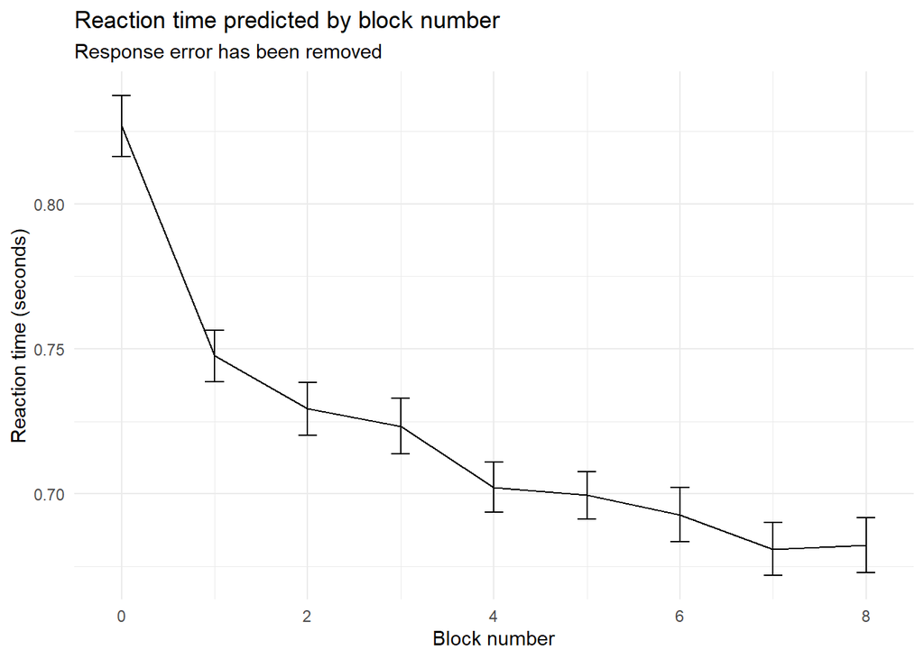

```r
# Plot for consistency
block_model_rt_block <- anova_rt_block_data %>%
  select(participant, expBlock.thisN, rt_pagg) %>%
  na.omit() %>%
  group_by(expBlock.thisN) %>%
  summarize(mean = mean(rt_pagg),
            sd = sd(rt_pagg),
            se = sd(rt_pagg)/sqrt(length(rt_pagg)))

ggplot(block_model_rt_block, aes(x = expBlock.thisN,
                                      y = mean,
                                      fill = expBlock.thisN)) +
  geom_line() +
  theme_minimal() +
  theme(legend.position = "none") +
  labs(title = "Reaction time predicted by block number",
       subtitle = "Response error has been removed",
       x = "Block number",
       y = "Reaction time (seconds)") +
  geom_errorbar(aes(ymin = mean - se, ymax = mean + se), width = .2,
                position = position_dodge(.9))
```

# Model predicting error with block as predictor

```r
# Organizing data to include bothlevels of error but get rid of the dislike condition
anova_error_data_block <- data_rt %>%
  filter(consistent != "Dislike") %>%
  droplevels(data_rt$consistent) %>%
  na.omit() %>%
  group_by(participant, visibility_effects, consistent, error, expBlock.thisN) %>%
  unique() %>%
  count() %>%
  mutate(n_per_grouping = n)

anova_error_data_block2 <- anova_error_data_block %>%
  group_by(participant, expBlock.thisN) %>%
  mutate(n_per_total = sum(n_per_grouping))

anova_error_data_block3 <- anova_error_data_block2 %>%
  mutate(n_per_grouping = ifelse(error == "Correct", 0, ifelse(error == "Error", n_per_grouping, NA))) %>%
  mutate(error_per_group = (n_per_grouping/n_per_total)*100)

anova_error_data_block4 <- anova_error_data_block3 %>%
  group_by(participant, visibility_effects, consistent, expBlock.thisN) %>%
  mutate(error_rate = mean(error_per_group)) %>%
  select(participant, visibility_effects, consistent, error_rate, expBlock.thisN) %>%
  unique()

# Applying helmert contrasts to consistent; visibility is already effects coded
contrasts(anova_error_data_block3$consistent) <- ConCodes
contrasts(anova_error_data_block3$consistent)
```

```
##              CIvU CvI
## Consistent     -1  -1
## Inconsistent   -1   1
## Unknown         2   0
```

## Anova Results

```r
# Running logistic regression predicting error
model4 <- with(anova_error_data_block4,
                  aov(error_rate ~ (visibility_effects*consistent*expBlock.thisN) +
                        Error(participant/(visibility_effects*consistent*expBlock.thisN))))


summary(model4)
```

```
##
## Error: participant
##           Df Sum Sq Mean Sq F value Pr(>F)
## Residuals  1  50.68   50.68
##
## Error: participant:visibility_effects
##                    Df Sum Sq Mean Sq
## visibility_effects  1   0.11    0.11
##
## Error: participant:consistent
##            Df Sum Sq Mean Sq
## consistent  2  92.89   46.45
##
## Error: participant:expBlock.thisN
##                Df  Sum Sq Mean Sq
## expBlock.thisN  1 0.01664 0.01664
##
## Error: participant:visibility_effects:consistent
##                               Df Sum Sq Mean Sq
## visibility_effects:consistent  2  0.163 0.08148
##
## Error: participant:visibility_effects:expBlock.thisN
##                                   Df Sum Sq Mean Sq
## visibility_effects:expBlock.thisN  1 0.3072  0.3072
##
## Error: participant:consistent:expBlock.thisN
##                           Df Sum Sq Mean Sq
## consistent:expBlock.thisN  2  1.542  0.7711
##
## Error: participant:visibility_effects:consistent:expBlock.thisN
##                                              Df Sum Sq Mean Sq
## visibility_effects:consistent:expBlock.thisN  2 0.2614  0.1307
##
## Error: Within
##                                                Df Sum Sq Mean Sq F value Pr(>F)
## visibility_effects                              1      0    0.01   0.011  0.917
## consistent                                      2    159   79.51  67.097 <2e-16
## expBlock.thisN                                  1      1    0.59   0.495  0.482
## visibility_effects:consistent                   2      0    0.10   0.086  0.917
## visibility_effects:expBlock.thisN               1      0    0.01   0.006  0.940
## consistent:expBlock.thisN                       2      3    1.41   1.192  0.304
## visibility_effects:consistent:expBlock.thisN    2      1    0.61   0.517  0.596
## Residuals                                    5052   5987    1.19
##
## visibility_effects
## consistent                                   ***
## expBlock.thisN
## visibility_effects:consistent
## visibility_effects:expBlock.thisN
## consistent:expBlock.thisN
## visibility_effects:consistent:expBlock.thisN
## Residuals
## ---
## Signif. codes:  0 '***' 0.001 '**' 0.01 '*' 0.05 '.' 0.1 ' ' 1
```

```r
model4 <- aov_car(error_rate ~ Error(participant/(visibility_effects*consistent*expBlock.thisN)),
                      data = anova_error_data_block4, anova_table = list(p_adjust_method = "bonferroni"))

summary(model4) #without bonferroni adjustment
```

```
##
## Univariate Type III Repeated-Measures ANOVA Assuming Sphericity
##
##                                               Sum Sq num Df Error SS den Df
## (Intercept)                                  1443.55      1  2881.24     93
## visibility_effects                              0.12      1    35.06     93
## consistent                                    210.46      2  1215.52    186
## expBlock.thisN                                  3.31      8   348.58    744
## visibility_effects:consistent                   0.33      2    82.54    186
## visibility_effects:expBlock.thisN               2.97      8   295.54    744
## consistent:expBlock.thisN                       7.73     16   606.97   1488
## visibility_effects:consistent:expBlock.thisN   10.70     16   595.66   1488
##                                              F value    Pr(>F)
## (Intercept)                                  46.5944 8.794e-10 ***
## visibility_effects                            0.3158   0.57551
## consistent                                   16.1024 3.551e-07 ***
## expBlock.thisN                                0.8822   0.53096
## visibility_effects:consistent                 0.3676   0.69288
## visibility_effects:expBlock.thisN             0.9351   0.48656
## consistent:expBlock.thisN                     1.1846   0.27269
## visibility_effects:consistent:expBlock.thisN  1.6712   0.04583 *
## ---
## Signif. codes:  0 '***' 0.001 '**' 0.01 '*' 0.05 '.' 0.1 ' ' 1
##
##
## Mauchly Tests for Sphericity
##
##                                              Test statistic    p-value
## consistent                                          0.30602 0.0000e+00
## expBlock.thisN                                      0.20085 0.0000e+00
## visibility_effects:consistent                       0.63918 1.1448e-09
## visibility_effects:expBlock.thisN                   0.27275 9.2070e-11
## consistent:expBlock.thisN                           0.01247 0.0000e+00
## visibility_effects:consistent:expBlock.thisN        0.01306 0.0000e+00
##
##
## Greenhouse-Geisser and Huynh-Feldt Corrections
##  for Departure from Sphericity
##
##                                               GG eps Pr(>F[GG])
## consistent                                   0.59033  4.201e-05 ***
## expBlock.thisN                               0.73384    0.50578
## visibility_effects:consistent                0.73485    0.62744
## visibility_effects:expBlock.thisN            0.75080    0.46925
## consistent:expBlock.thisN                    0.65528    0.29513
## visibility_effects:consistent:expBlock.thisN 0.64512    0.08018 .
## ---
## Signif. codes:  0 '***' 0.001 '**' 0.01 '*' 0.05 '.' 0.1 ' ' 1
##
##                                                 HF eps   Pr(>F[HF])
## consistent                                   0.5934540 4.049726e-05
## expBlock.thisN                               0.7888432 5.116392e-01
## visibility_effects:consistent                0.7437548 6.300079e-01
## visibility_effects:expBlock.thisN            0.8083920 4.737575e-01
## consistent:expBlock.thisN                    0.7449666 2.891463e-01
## visibility_effects:consistent:expBlock.thisN 0.7319549 6.972059e-02
```

```r
nice(model4) #with bonferroni adjustment
```

```
## Anova Table (Type 3 tests, bonferroni-adjusted)
##
## Response: error_rate
##                                         Effect            df   MSE         F
## 1                           visibility_effects         1, 93  0.38      0.32
## 2                                   consistent  1.18, 109.80 11.07 16.10 ***
## 3                               expBlock.thisN  5.87, 545.98  0.64      0.88
## 4                visibility_effects:consistent  1.47, 136.68  0.60      0.37
## 5            visibility_effects:expBlock.thisN  6.01, 558.59  0.53      0.94
## 6                    consistent:expBlock.thisN 10.48, 975.06  0.62      1.18
## 7 visibility_effects:consistent:expBlock.thisN 10.32, 959.94  0.62      1.67
##     ges p.value
## 1 <.001   >.999
## 2  .034   <.001
## 3 <.001   >.999
## 4 <.001   >.999
## 5 <.001   >.999
## 6  .001   >.999
## 7  .002    .561
## ---
## Signif. codes:  0 '***' 0.001 '**' 0.01 '*' 0.05 '+' 0.1 ' ' 1
##
## Sphericity correction method: GG
```

```r
# Using emmeans to get marginal means for pairwise comparisons - smooth code for marginal means! These look like what I get when I hard code this by hand using dplyr
mm_consistent_model4 <- emmeans(model4, ~ consistent)

# Tukey pairwise comparisons - what I expected from the plots
pairs(mm_consistent_model4)
```

```
##  contrast                  estimate     SE  df t.ratio p.value
##  Consistent - Inconsistent   -0.364 0.0879 186 -4.146  0.0002
##  Consistent - Unknown        -0.477 0.0879 186 -5.429  <.0001
##  Inconsistent - Unknown      -0.113 0.0879 186 -1.282  0.4070
##
## Results are averaged over the levels of: visibility_effects, expBlock.thisN
## P value adjustment: tukey method for comparing a family of 3 estimates
```

## Descriptives for consistency

```r
data_aggregated_errorrate_block_con <- anova_error_data_block4 %>%
  select(participant, consistent, error_rate) %>%
  na.omit() %>%
  group_by(consistent) %>%
  summarize(mean = mean(error_rate),
            sd = sd(error_rate),
            se = sd(error_rate)/sqrt(length(error_rate)))
data_aggregated_errorrate_block_con
```

```
## # A tibble: 3 x 4
##   consistent    mean    sd     se
##   <fct>        <dbl> <dbl>  <dbl>
## 1 Consistent   0.253 0.594 0.0144
## 2 Inconsistent 0.617 1.27  0.0308
## 3 Unknown      0.730 1.28  0.0311
```

## Descriptives for visibility

```r
data_aggregated_errorrate_block_vis <- anova_error_data_block4 %>%
  select(participant, visibility_effects, error_rate) %>%
  na.omit() %>%
  group_by(visibility_effects) %>%
  summarize(mean = mean(error_rate),
            sd = sd(error_rate),
            se = sd(error_rate)/sqrt(length(error_rate)))
data_aggregated_errorrate_block_vis
```

```
## # A tibble: 2 x 4
##   visibility_effects  mean    sd     se
##   <fct>              <dbl> <dbl>  <dbl>
## 1 .5                 0.528  1.11 0.0221
## 2 -.5                0.538  1.12 0.0222
```

## Plot for marginal three-way interaction

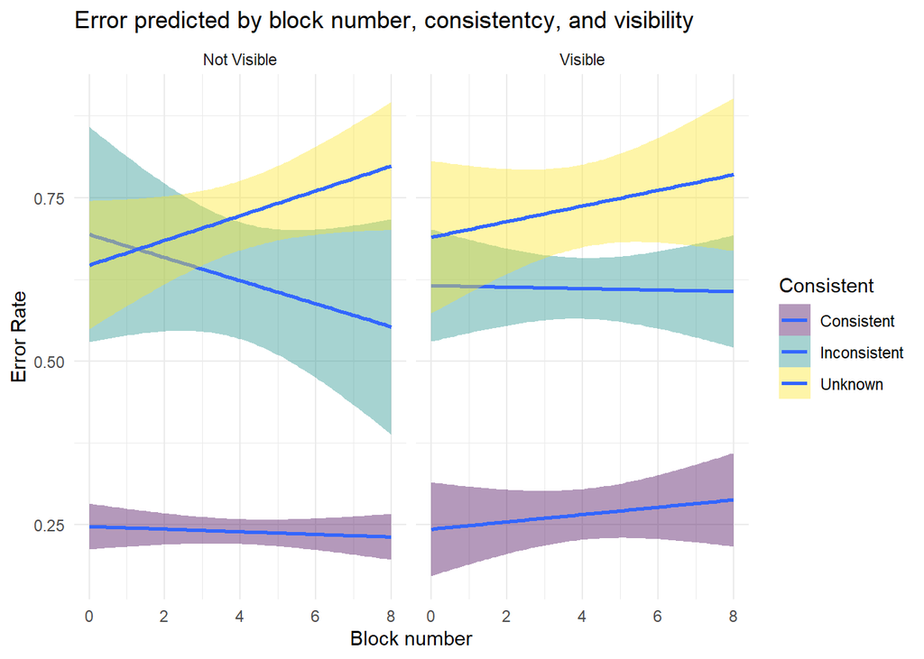

```r
threeway_block_error_plot <- anova_error_data_block4 %>%
  mutate(visibility_effects = recode(visibility_effects,
                                     `.5` = "Not Visible",
                                     `-.5` = "Visible"),
         Consistent = consistent) %>%
  select(participant, visibility_effects, Consistent, expBlock.thisN, error_rate) %>%
  na.omit() %>%
  group_by(visibility_effects, Consistent, expBlock.thisN) %>%
  summarize(mean = mean(error_rate),
            sd = sd(error_rate),
            se = sd(error_rate)/sqrt(length(error_rate)))

ggplot(threeway_block_error_plot, aes(x = expBlock.thisN,
                                      y = mean,
                                      fill = Consistent)) +
  geom_smooth(method = "lm") +
  facet_wrap(~visibility_effects) +
  theme_minimal() +
  labs(title = "Error predicted by block number, consistentcy, and visibility",
       x = "Block number",
       y = "Error Rate") +
  scale_fill_viridis_d()
```

# Demographics

## Number of participants with demographic data

```r
data_comb %>%
  select(participant) %>%
  unique() %>%
  nrow()
```

```
## [1] 94
```

## Gender

```r
data_comb %>%
  select(participant, gender) %>%
  na.omit() %>%
  unique() %>%
  group_by(gender) %>%
  count()
```

```
## # A tibble: 3 x 2
## # Groups:   gender [3]
##   gender                                             n
##   <chr>                                          <int>
## 1 Female                                            68
## 2 Male                                              21
## 3 Nonbinary (feel free to elaborate if you wish)     2
```

## Race

```r
race1 <- data_comb %>%
  select(participant, race) %>%
  na.omit() %>%
  unique() %>%
  group_by(race) %>%
  count()

race1 %>%
  mutate(total_n = sum(race1$n[1:7])) %>%
  mutate(percent = n/total_n*100)
```

```
## # A tibble: 7 x 4
## # Groups:   race [7]
##   race                                     n total_n percent
##   <chr>                                <int>   <int>   <dbl>
## 1 Asian or Asian American                 13      92   14.1
## 2 Black or African American                3      92    3.26
## 3 Latino/Hispanic/Chicano/Puerto Rican    11      92   12.0
## 4 Middle Eastern or North African          2      92    2.17
## 5 Multiracial                             11      92   12.0
## 6 Native Hawaiian or Pacific Islander      1      92    1.09
## 7 White or European American              51      92   55.4
```

## Age

```r
data_comb %>%
  select(participant, age) %>%
  na.omit() %>%
  summarize(mean = mean(age),
            sd = sd(age))
```

```
## # A tibble: 1 x 2
##    mean    sd
##   <dbl> <dbl>
## 1  19.0  1.19
```

## Class level

```r
data_comb %>%
  select(participant, class_level) %>%
  na.omit() %>%
  unique() %>%
  group_by(class_level) %>%
  count()
```

```
## # A tibble: 5 x 2
## # Groups:   class_level [5]
##   class_level                n
##   <chr>                  <int>
## 1 Freshman                  51
## 2 Junior                    14
## 3 Other (Please specify)     2
## 4 Senior                     8
## 5 Sophomore                 17
```

## Parent’s education

```r
data_comb %>%
  select(participant, parents_edu) %>%
  na.omit() %>%
  unique() %>%
  group_by(parents_edu) %>%
  count()
```

```
## # A tibble: 8 x 2
## # Groups:   parents_edu [8]
##   parents_edu                          n
##   <chr>                            <int>
## 1 2 year degree/Associate degree       4
## 2 4 year degree/Bachelor's degree     28
## 3 Doctorate or Professional degree    10
## 4 High school graduate                 8
## 5 Less than high school                4
## 6 Master's degree                     24
## 7 Some college                        11
## 8 Some graduate school                 3
```

## Native language

```r
data_comb %>%
  select(participant, english_native) %>%
  na.omit() %>%
  unique() %>%
  group_by(english_native) %>%
  count()
```

```
## # A tibble: 2 x 2
## # Groups:   english_native [2]
##   english_native     n
##   <chr>          <int>
## 1 No                 9
## 2 Yes               82
```

## Born in the US

```r
data_comb %>%
  select(participant, us_birth_country) %>%
  na.omit() %>%
  unique() %>%
  group_by(us_birth_country) %>%
  count()
```

```
## # A tibble: 2 x 2
## # Groups:   us_birth_country [2]
##   us_birth_country     n
##   <chr>            <int>
## 1 No                   9
## 2 Yes                 82
```

## Raised in the US

```r
data_comb %>%
  select(participant, us_raised) %>%
  na.omit() %>%
  unique() %>%
  group_by(us_raised) %>%
  count()
```

```
## # A tibble: 2 x 2
## # Groups:   us_raised [2]
##   us_raised     n
##   <chr>     <int>
## 1 No            3
## 2 Yes          88
```